# AS06. Gender Data Visualization

莊千逸

2025-05-09

# 女性為主的居家托育人力：從地圖與年份看性別差異的空間與時間變化

## 詮釋資料

- **name**：居家托育服務登記證書人數
- **資料範圍**：2013–2023（民國102–112年）
- **href**：[行政院性別平等資料平台](https://www.gender.ey.gov.tw/gecdb/Stat_Statistics_DetailData.aspx?sn=JRmS!SQJS1Wg3AF1jb73YA%40%40&d=194q2o4!otzoYO!8OAMYew%40%40)
  - ([https://www.gender.ey.gov.tw/gecdb/Stat_Statistics_DetailData.aspx?sn=JRmS!SQJS1Wg3AF1jb73YA%40%40&d=194q2o4!otzoYO!8OAMYew%40%40)](https://www.gender.ey.gov.tw/gecdb/Stat_Statistics_DetailData.aspx?sn=JRmS!SQJS1Wg3AF1jb73YA%40%40&d=194q2o4!otzoYO!8OAMYew%40%40))
- **def**：衛生福利部社會及家庭署
- **cat1**：健康、醫療與照顧
- **cat2**：兒童照顧
- **複分類**：年度別，縣市別，性別

## 資料處理

```r
raw_data <- fromJSON("居家托育服務登記證書人數─按性別縣市別分.json")


clean_data <- raw_data %>%
  filter(Category1Title %in% c("男", "女")) %>%
  select(year = Period, gender = Category1Title, county = Category2Title, value = Val) %>%
  mutate(year = as.integer(year / 100))


wide_data <- clean_data %>%
  pivot_wider(names_from = gender, values_from = value) %>%
  mutate(ratio = (女 - 男) / (女 + 男))
```

## 指標說明

我採用「性別差異指標」此綜合性指標，定義如下：

$$\text{性別差異指標} = \frac{\text{女性人數} -
\text{男性人數}}{\text{女性人數} + \text{男性人數}}$$

該指標可反映女性佔總人數的程度，值越接近 1 表示女性比例越高；值越接近 0 表示男女比例越平衡。本指標經標準化後，能排除各縣市總人數不同所造成的影響 ，使得性別差異具有可比性。

## 地圖讀取與合併（使用 tw.json GeoJSON + 完整對照表）

```r
county_dict <- tibble::tibble(
  COUNTYNAME = c(
    "Taipei", "Taipei City", "New Taipei", "New Taipei City",
    "Taoyuan", "Taichung", "Taichung City",
    "Tainan", "Tainan City", "Kaohsiung", "Kaohsiung City",
    "Keelung", "Keelung City", "Hsinchu", "Hsinchu City",
    "Chiayi", "Chiayi City", "Hsinchu County", "Miaoli", "Changhua", "Nantou",
    "Yunlin", "Chiayi County", "Pingtung", "Yilan", "Hualien", "Taitung",
    "Penghu", "Kinmen", "Lienchiang", "Matsu Islands"
  ),
  county = c(
    "臺北市", "臺北市", "新北市", "新北市",
    "桃園市", "臺中市", "臺中市",
    "臺南市", "臺南市", "高雄市", "高雄市",
    "基隆市", "基隆市", "新竹市", "新竹市",
    "嘉義市", "嘉義市", "新竹縣", "苗栗縣", "彰化縣", "南投縣",
    "雲林縣", "嘉義縣", "屏東縣", "宜蘭縣", "花蓮縣", "臺東縣",
    "澎湖縣", "金門縣", "連江縣", "連江縣"
  )
)


data_2023 <- wide_data %>%
  filter(year == 112) %>%
  mutate(
    county = as.character(county),
    county = str_replace_all(county, "台", "臺"),
    county = str_trim(county)
  )


map_sf <- sf::read_sf("tw.json") %>%
  rename(COUNTYNAME_EN = name) %>%
  left_join(county_dict, by = c("COUNTYNAME_EN" = "COUNTYNAME"))


map_merged <- map_sf %>%
  left_join(data_2023, by = c("county" = "county"))
```

## 2023年各縣市居家托育證書人員性別差異指標地圖

```
## ── tmap v3 code detected ───────────────────────────────────────────────────────
```

[output not shown]

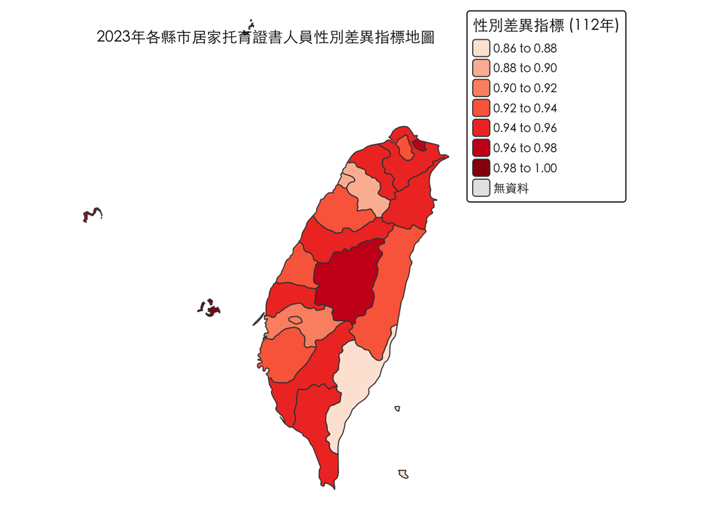

```r
tm_shape(map_merged) +
  tm_polygons("ratio", palette = "Reds", title = "性別差異指標 (112年)",
              textNA = "無資料", colorNA = "grey90") +
  tm_layout(
    title = "2023年各縣市居家托育證書人員性別差異指標地圖",
    fontfamily = "Heiti TC Light",
    frame = FALSE
  )
```

## 各縣市性別差異排序圖（2023年）

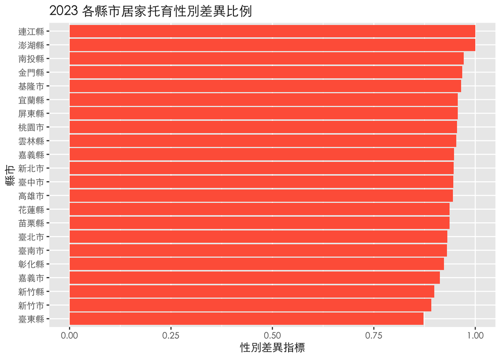

```r
library(forcats)

data_2023 %>%
  filter(county != "總計") %>%
  mutate(county = fct_reorder(county, ratio)) %>%
  ggplot(aes(x = county, y = ratio)) +
  geom_col(fill = "tomato") +
  coord_flip() +
  labs(title = "2023 各縣市居家托育性別差異比例",
       x = "縣市", y = "性別差異指標") +
  theme(text = element_text(family = "Heiti TC Light"))
```

## 2013–2023年全國居家托育性別差異指標趨勢圖

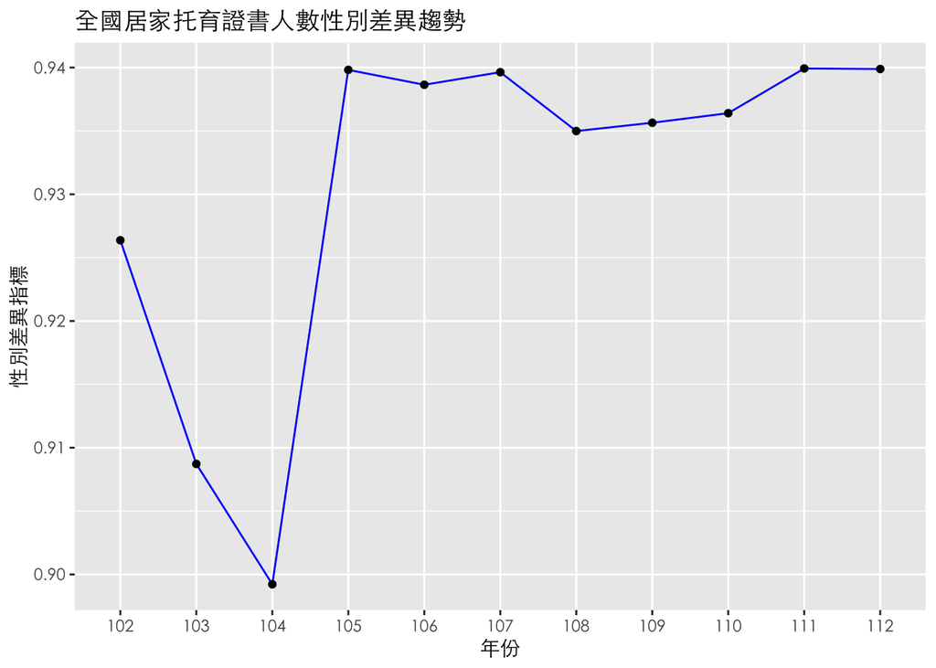

```r
trend_data <- wide_data %>%
  group_by(year) %>%
  summarise(total_f = sum(女, na.rm = TRUE),
            total_m = sum(男, na.rm = TRUE),
            ratio = (total_f - total_m) / (total_f + total_m))

ggplot(trend_data, aes(x = factor(year), y = ratio, group = 1)) +
  geom_line(color = "blue") +
  geom_point() +
  labs(title = "全國居家托育證書人數性別差異趨勢",
       y = "性別差異指標", x = "年份") +
  theme(text = element_text(family = "Heiti TC Light"))
```

## FINDINGS

根據視覺化結果顯示，居家托育證書人數普遍以女性為主，反映出托育職業長期受性別角色影響。值得注意的是，104 年性別差異指標出現明顯下滑，推測與 103 年底正式施行之「居家式托育服務登記制度」有關。該政策啟動後，可能吸引特定時期內大量托育人員登記，其中男性比例相對提高，導致該年性別差異指標短暫趨於平衡。此現象在後續年度迅速回落，顯示該變動具有政策導向下的一次性特徵。

```r
wide_data %>%
  filter(year == 104) %>%
  arrange(desc((女 - 男) / (女 + 男)))
```

```
## # A tibble: 23 × 5
##     year county    男    女 ratio
##    <int> <chr>  <dbl> <dbl> <dbl>
##  1   104 屏東縣    22   687 0.938
##  2   104 嘉義市    25   620 0.922
##  3   104 嘉義縣    24   587 0.921
##  4   104 基隆市    33   773 0.918
##  5   104 宜蘭縣    46  1017 0.913
##  6   104 桃園市   186  3924 0.909
##  7   104 南投縣    48   990 0.908
##  8   104 臺中市   345  7032 0.906
##  9   104 高雄市   237  4758 0.905
## 10   104 雲林縣    42   834 0.904
## # ℹ 13 more rows
```

```r
wide_data %>%
  group_by(year) %>%
  summarise(總計 = sum(男 + 女, na.rm = TRUE))
```

```
## # A tibble: 11 × 2
##     year  總計
##    <int> <dbl>
##  1   102 68398
##  2   103 83698
##  3   104 97362
##  4   105 48518
##  5   106 51500
##  6   107 52480
##  7   108 52544
##  8   109 54198
##  9   110 55094
## 10   111 54268
## 11   112 54562
```

（從以上資料顯示，104 年為居家托育證書人數高峰，性別差異指標卻異常下降。）